# lab-2.2

## Lab-2.2: Binary and multi-class classification via neural-networks

- In this lab we perform binary classification on the IMDB dataset and multi-class classification on the Newswire data-set.

**Instructions**

- Code both binary and multi-class using a deep feed forward fully connected Neural network
  - Binary classification: IMDB data-set
  - Multi-class classification: Newswire data-set
  - **Do each example with Keras AND then Pytorch**
  - Use a dense feed forward ANN model
  - Normalize the data as needed
  - Visualize the results at the end where possible
  - Partition data into training, validation, and test
  - Monitor training and validation throughout training by plotting
  - Print training, validation, and test errors at the very end
  - Do basic hyper parameter tuning to try to achieve an optimal fit model
    - i.e. best training/validation loss without over-fitting
    - Explore L1 and L2 regularization
    - Explore different optimizers
    - Use the loss functions specified in the textbook
    - Explore different options for activation functions, network size/depth, etc
- **Document what is going on in the code, as needed, with narrative markdown text between cells.**
- *Submit the version with hyper parameters that provide the optimal fit*
  - i.e. you don't need to show the outputs of your hyper-parameter tuning process

**Important: The Keras portion of this assignment is included as an example in the text book**

- Binary classification: See the textbook (Chollet chapter-3, page 68) for reference
- Multi-class classification: See the textbook (Chollet chapter-3, page 78) for reference

**Submission:**

- You need to upload ONE document to Canvas when you are done
  - (1) A PDF (or HTML) of the completed form of this notebook
- The final uploaded version should NOT have any code-errors present
- All outputs must be visible in the uploaded version, including code-cell outputs, images, graphs, etc

```python
import pandas as pd
import numpy as np
import sklearn
import matplotlib.pyplot as plt
```

[output not shown]

## Binary Classification

### Data preparation

- Insert cells below

```python
from keras.datasets import imdb
(train_data,train_labels),(test_data,test_labels)=imdb.load_data(num_words=10000)
```

```python
train_data[:1]
```

```
array([list([1, 14, 22, 16, 43, 530, 973, 1622, 1385, 65, 458, 4468, 66, 3941, 4, 173, 36, 256, 5, 25, 100, 43, 838, 112, 50, 670, 2, 9, 35, 480, 284, 5, 150, 4, 172, 112, 167, 2, 336, 385, 39, 4, 172, 4536, 1111, 17, 546, 38, 13, 447, 4, 192, 50, 16, 6, 147, 2025, 19, 14, 22, 4, 1920, 4613, 469, 4,…
      dtype=object)
```

```python
print("train:",train_data.shape)
print("test:",test_data.shape)
```

```
train: (25000,)
test: (25000,)
```

```python
pd.Series(train_labels).value_counts()
```

```
1    12500
0    12500
dtype: int64
```

```python
pd.Series(test_labels).value_counts()
```

```
0    12500
1    12500
dtype: int64
```

```python
#Check num of word dimensions
max([max(text) for text in train_data])
```

```
9999
```

```python
#BOW
import numpy as np
def vectorize_sequences(sequences,dimension=10000):
    results=np.zeros((len(sequences),dimension))
    for i,sequence in enumerate(sequences):
        results[i,sequence]+=1
    return results

X_train=vectorize_sequences(train_data)
X_test=vectorize_sequences(test_data)
```

```python
X_train.shape
```

```
(25000, 10000)
```

```python
train_labels.shape
```

```
(25000,)
```

```python
#Get validation data
X_val=X_train[20000:,]
y_val=train_labels[20000:,]

X_train=X_train[:20000,]
y_train=train_labels[:20000,]

X_test=X_test[:5000]
y_test=test_labels[:5000]
```

```python
print("train:",X_train.shape)
print("validation:",X_val.shape)
print("test:",X_test.shape)
```

```
train: (20000, 10000)
validation: (5000, 10000)
test: (5000, 10000)
```

### Keras training

- Insert cells below

```python
#Compile Model
from keras import models
from keras import layers
from keras import optimizers
import warnings
warnings.filterwarnings('ignore')

model=models.Sequential()
model.add(layers.Dense(16,input_shape=(10000,),activation='relu'))
model.add(layers.Dense(16,activation='relu'))
model.add(layers.Dense(1,activation='sigmoid'))
model.compile(optimizer=optimizers.RMSprop(lr=0.0001),loss='binary_crossentropy',metrics=['accuracy'])

history=model.fit(X_train,y_train,epochs=100,batch_size=512,validation_data=(X_val,y_val),verbose=False)
```

[output not shown]

[output not shown]

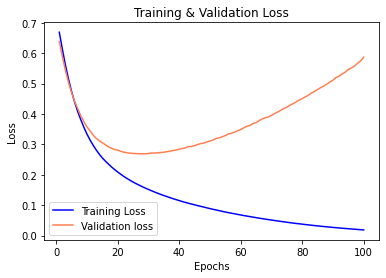

```python
history_dict=history.history
loss_values=history_dict['loss']
val_loss_values=history_dict['val_loss']
epochs=range(1,len(loss_values)+1)

plt.plot(epochs,loss_values,'b',label='Training Loss')
plt.plot(epochs,val_loss_values,'b',label='Validation loss',color='coral')
plt.title('Training & Validation Loss')
plt.xlabel('Epochs')
plt.ylabel('Loss')
plt.legend()
plt.show()
```

```python
#Early stop point
np.argmin(history_dict['val_loss'])
```

```
27
```

```python
#Early stop
model=models.Sequential()
model.add(layers.Dense(16,input_shape=(10000,),activation='relu'))
model.add(layers.Dense(16,activation='relu'))
model.add(layers.Dense(1,activation='sigmoid'))
model.compile(optimizer=optimizers.RMSprop(lr=0.0001),loss='binary_crossentropy',metrics=['accuracy'])

history=model.fit(X_train,y_train,epochs=np.argmin(history_dict['val_loss']),batch_size=512,validation_data=(X_val,y_val),verbose=False)
```

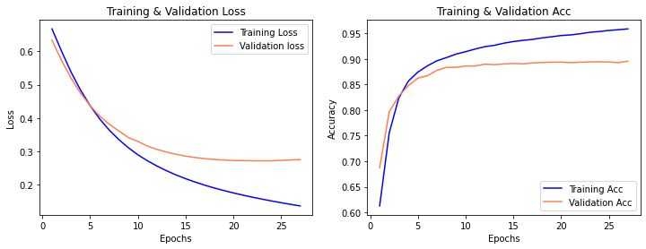

```python
history_dict=history.history
loss_values=history_dict['loss']
val_loss_values=history_dict['val_loss']
train_acc=history_dict['accuracy']
valid_acc=history_dict['val_accuracy']

epochs=range(1,len(loss_values)+1)

plt.figure(figsize=(12,4))

plt.subplot(1,2,1)
plt.plot(epochs,loss_values,'b',label='Training Loss')
plt.plot(epochs,val_loss_values,'b',label='Validation loss',color='coral')
plt.title('Training & Validation Loss')
plt.xlabel('Epochs')
plt.ylabel('Loss')
plt.legend()

plt.subplot(1,2,2)
plt.plot(epochs,train_acc,'b',label='Training Acc')
plt.plot(epochs,valid_acc,'b',label='Validation Acc',color='coral')
plt.title('Training & Validation Acc')
plt.xlabel('Epochs')
plt.ylabel('Accuracy')
plt.legend()

plt.show()
```

```python
import plotly.express as px
from sklearn.metrics import roc_curve,roc_auc_score
y_pred=model.predict(X_test)
fpr,tpr,thresholds=roc_curve(y_test,y_pred)
fig=px.line(data_frame=pd.DataFrame({'FPR':fpr,'TPR':tpr,'Threshold':thresholds}),x='FPR',y='TPR',custom_data=['Threshold'],title='ROC for Test')
fig.update_traces(
    hovertemplate="<br>".join([
        "Threshold: %{customdata[0]}",
        "FPR: %{x}",
        "TPR: %{y}"
    ])
)
fig.show()

print('AUC:',roc_auc_score(y_test,y_pred))
```

[interactive chart not shown]

```
AUC: 0.9512049638756636
```

### Pytorch training

- Insert cells below

```python
import torch
from torch import nn
from torchvision.transforms import ToTensor
device='cpu'
```

```python
class NeuralNetwork(nn.Module):
    def __init__(self):
        super(NeuralNetwork, self).__init__()
        self.flatten = nn.Flatten()
        self.linear_relu_stack = nn.Sequential(
            nn.Linear(10000, 16),
            nn.ReLU(),
            nn.Linear(16, 16),
            nn.ReLU(),
            nn.Linear(16,2),
            nn.Sigmoid()
        )

    def forward(self, x):
        x = self.flatten(x)
        logits = self.linear_relu_stack(x)
        return logits

model = NeuralNetwork().to('cpu')
print(model)
```

```
NeuralNetwork(
  (flatten): Flatten(start_dim=1, end_dim=-1)
  (linear_relu_stack): Sequential(
    (0): Linear(in_features=10000, out_features=16, bias=True)
    (1): ReLU()
    (2): Linear(in_features=16, out_features=16, bias=True)
    (3): ReLU()
    (4): Linear(in_features=16, out_features=2, bias=True)
    (5): Sigmoid()
  )
)
```

```python
#Loss & Optimizer
loss_fn = nn.CrossEntropyLoss()
optimizer = torch.optim.SGD(model.parameters(), lr=0.5)
#INITIALIZE ARRAYS TO SAVE HISTORY
epoch_array=[]
val_loss_history=[]
train_loss_history=[]
```

```python
def one_hot(x):
    tmp=[0.,0.]
    tmp[int(x.numpy())]=1.
    return tmp

def train(x_train,y_train, model, loss_fn, optimizer):
    #TELL MODEL IT SHOULD BE TRAINING
    model.train()

    #BATCH IMPLEMENTATION
    X, y = torch.from_numpy(x_train).to(device).float(), torch.from_numpy(y_train).to(device).float()

    y=torch.tensor([one_hot(label) for label in y])
    # Compute prediction error
    pred = model(X)

    loss = loss_fn(pred, y)

    # Backpropagation
    optimizer.zero_grad()
    loss.backward()
    optimizer.step()

    # if t % 5 == 0:
    loss = loss.item()
    train_loss_history.append(loss)

    if(i_print):
        print(f"loss: {loss:>7f}")
```

```python
def validate(x_val,y_val, model, loss_fn):
    #TELL MODEL IT SHOULD BE EVALUATING
    model.eval()
    X, y = torch.from_numpy(x_val).to(device).float(), torch.from_numpy(y_val).to(device).float()
    y=torch.tensor([one_hot(label) for label in y])
    pred = model(X)

    val_loss = loss_fn(pred, y)
    val_loss_history.append(val_loss)
    if(i_print):
        print(f"Test Error: {val_loss:>8f}")
```

```python
epochs = 81

for t in range(epochs):
    epoch_array.append(t)
    if t%10==0:
        i_print=True
        print(f"-------------------------------\nEpoch {t}")

    else:
        i_print=False

    train(X_train,y_train, model, loss_fn, optimizer)
    validate(X_val,y_val, model, loss_fn)
print("Done!")
```

```
-------------------------------
Epoch 0
loss: 0.530553
Test Error: 0.538615
-------------------------------
Epoch 10
loss: 0.515357
Test Error: 0.523437
-------------------------------
Epoch 20
loss: 0.503066
Test Error: 0.511266
-------------------------------
Epoch 30
loss: 0.492666
Test Error: 0.501289
-------------------------------
Epoch 40
loss: 0.483705
Test Error: 0.493037
-------------------------------
Epoch 50
loss: 0.476068
Test Error: 0.486190
-------------------------------
Epoch 60
loss: 0.469402
Test Error: 0.480432
-------------------------------
Epoch 70
loss: 0.463882
Test Error: 0.475855
-------------------------------
Epoch 80
loss: 0.459311
Test Error: 0.472226
Done!
```

[figure not shown]

```python
loss_values=train_loss_history
val_loss_values=[loss.item() for loss in val_loss_history]

epochs=range(1,len(loss_values)+1)

plt.plot(epochs,loss_values,'b',label='Training Loss')
plt.plot(epochs,val_loss_values,'b',label='Validation loss',color='coral')
plt.title('Training & Validation Loss')
plt.xlabel('Epochs')
plt.ylabel('Loss')
plt.legend()

plt.show()
```

```python
def test(x_test,y_test, model):
    #TELL MODEL IT SHOULD BE EVALUATING
    model.eval()
    X, y = torch.from_numpy(x_test).to(device).float(), torch.from_numpy(y_test).to(device).float()
    y=torch.tensor([one_hot(label) for label in y])
    pred = model(X).argmax(dim=1).numpy()
    y=y.argmax(dim=1).numpy()
    print("Test Accuracy:{:2.2f}".format(np.sum(pred==y)/len(y)))
```

```python
test(X_test,y_test, model)
```

```
Test Accuracy:0.82
```

## Multi-class Classification

### Data preparation

- Insert cells below

```python
from keras.datasets import reuters
(train_data,train_labels),(test_data,test_labels)=reuters.load_data(num_words=10000)
```

```python
print("train:",train_data.shape)
print("test:",test_data.shape)
```

```
train: (8982,)
test: (2246,)
```

```python
pd.Series(train_labels).value_counts()
```

```
3     3159
4     1949
19     549
16     444
1      432
11     390
20     269
13     172
8      139
10     124
9      101
21     100
25      92
2       74
18      66
```

[output cut: 32 more lines]

```python
#Check num of word dimensions
max([max(text) for text in train_data])
```

```
9999
```

```python
#BOW
import numpy as np
def vectorize_sequences(sequences,dimension=10000):
    results=np.zeros((len(sequences),dimension))
    for i,sequence in enumerate(sequences):
        results[i,sequence]+=1
    return results

X_train=vectorize_sequences(train_data)
X_test=vectorize_sequences(test_data)
```

```python
#Get validation data
X_val=X_train[-2246:,]
y_val=train_labels[-2246:,]

X_train=X_train[:-2246,]
y_train=train_labels[:-2246,]
```

```python
print("train:",X_train.shape)
print("validation:",X_val.shape)
print("test:",X_test.shape)
```

```
train: (6736, 10000)
validation: (2246, 10000)
test: (2246, 10000)
```

### Keras training

- Insert cells below

```python
#Compile Model
from keras import models
from keras import layers
from keras import optimizers
import warnings
warnings.filterwarnings('ignore')
model=models.Sequential()
model.add(layers.Dense(64,input_shape=(10000,),activation='relu'))
model.add(layers.Dense(64,activation='relu'))
model.add(layers.Dense(46,activation='softmax'))
model.compile(optimizer=optimizers.RMSprop(lr=0.001),metrics=['accuracy'],loss='sparse_categorical_crossentropy')

history=model.fit(X_train,y_train,epochs=50,batch_size=512,validation_data=(X_val,y_val),verbose=False)
```

```
WARNING:tensorflow:From D:\Anaconda\lib\site-packages\keras\backend\tensorflow_backend.py:422: The name tf.global_variables is deprecated. Please use tf.compat.v1.global_variables instead.
```

[output not shown]

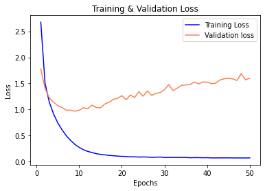

```python
import matplotlib.pyplot as plt
history_dict=history.history
loss_values=history_dict['loss']
val_loss_values=history_dict['val_loss']
epochs=range(1,len(loss_values)+1)

plt.plot(epochs,loss_values,'b',label='Training Loss')
plt.plot(epochs,val_loss_values,'b',label='Validation loss',color='coral')
plt.title('Training & Validation Loss')
plt.xlabel('Epochs')
plt.ylabel('Loss')
plt.legend()
plt.show()
```

```python
#Smaller lr and more epoch
model=models.Sequential()
model.add(layers.Dense(64,input_shape=(10000,),activation='relu'))
model.add(layers.Dense(64,activation='relu'))
model.add(layers.Dense(46,activation='softmax'))
model.compile(optimizer=optimizers.RMSprop(lr=0.0001),metrics=['accuracy'],loss='sparse_categorical_crossentropy')

history=model.fit(X_train,y_train,epochs=100,batch_size=512,validation_data=(X_val,y_val),verbose=False)
```

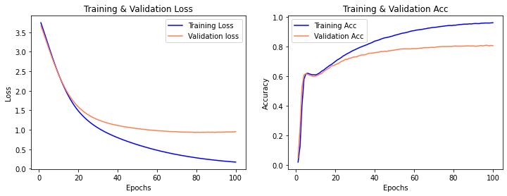

```python
history_dict=history.history
loss_values=history_dict['loss']
val_loss_values=history_dict['val_loss']
train_acc=history_dict['accuracy']
valid_acc=history_dict['val_accuracy']

epochs=range(1,len(loss_values)+1)

plt.figure(figsize=(12,4))

plt.subplot(1,2,1)
plt.plot(epochs,loss_values,'b',label='Training Loss')
plt.plot(epochs,val_loss_values,'b',label='Validation loss',color='coral')
plt.title('Training & Validation Loss')
plt.xlabel('Epochs')
plt.ylabel('Loss')
plt.legend()

plt.subplot(1,2,2)
plt.plot(epochs,train_acc,'b',label='Training Acc')
plt.plot(epochs,valid_acc,'b',label='Validation Acc',color='coral')
plt.title('Training & Validation Acc')
plt.xlabel('Epochs')
plt.ylabel('Accuracy')
plt.legend()

plt.show()
```

```python
#Test Performance
from sklearn.metrics import classification_report
y_pred=model.predict_classes(X_test)
print (classification_report(test_labels,y_pred))
```

```
              precision    recall  f1-score   support

           0       0.88      0.58      0.70        12
           1       0.66      0.85      0.74       105
           2       0.79      0.55      0.65        20
           3       0.89      0.95      0.92       813
           4       0.83      0.88      0.86       474
           5       0.00      0.00      0.00         5
           6       0.92      0.79      0.85        14
           7       1.00      0.33      0.50         3
           8       0.71      0.66      0.68        38
           9       0.86      0.76      0.81        25
          10       0.75      0.80      0.77        30
          11       0.63      0.73      0.68        83
          12       0.56      0.38      0.45        13
```

[output cut: 37 more lines]

### Pytorch training

- Insert cells below

```python
import torch
from torch import nn
from torchvision.transforms import ToTensor
device='cpu'

class NeuralNetwork(nn.Module):
    def __init__(self):
        super(NeuralNetwork, self).__init__()
        self.flatten = nn.Flatten()
        self.linear_relu_stack = nn.Sequential(
            nn.Linear(10000, 64),
            nn.ReLU(),
            nn.Linear(64, 64),
            nn.ReLU(),
            nn.Linear(64,46),
            nn.Softmax()
        )

    def forward(self, x):
        x = self.flatten(x)
        logits = self.linear_relu_stack(x)
        return logits

model = NeuralNetwork().to('cpu')
print(model)
```

```
NeuralNetwork(
  (flatten): Flatten(start_dim=1, end_dim=-1)
  (linear_relu_stack): Sequential(
    (0): Linear(in_features=10000, out_features=64, bias=True)
    (1): ReLU()
    (2): Linear(in_features=64, out_features=64, bias=True)
    (3): ReLU()
    (4): Linear(in_features=64, out_features=46, bias=True)
    (5): Softmax(dim=None)
  )
)
```

```python
#Loss & Optimizer
loss_fn = nn.CrossEntropyLoss()
optimizer = torch.optim.SGD(model.parameters(), lr=0.8)
#INITIALIZE ARRAYS TO SAVE HISTORY
epoch_array=[]
val_loss_history=[]
train_loss_history=[]
```

```python
def one_hot(x):
    tmp=[0.]*46
    tmp[int(x.numpy())]=1.
    return tmp

def train(x_train,y_train, model, loss_fn, optimizer):
    #TELL MODEL IT SHOULD BE TRAINING
    model.train()

    #BATCH IMPLEMENTATION
    X, y = torch.from_numpy(x_train).to(device).float(), torch.from_numpy(y_train).to(device).float()

    y=torch.tensor([one_hot(label) for label in y])
    # Compute prediction error
    pred = model(X)

    loss = loss_fn(pred, y)

    # Backpropagation
    optimizer.zero_grad()
    loss.backward()
    optimizer.step()

    # if t % 5 == 0:
    loss = loss.item()
    train_loss_history.append(loss)

    if(i_print):
        print(f"loss: {loss:>7f}")
```

```python
def validate(x_val,y_val, model, loss_fn):
    #TELL MODEL IT SHOULD BE EVALUATING
    model.eval()
    X, y = torch.from_numpy(x_val).to(device).float(), torch.from_numpy(y_val).to(device).float()
    y=torch.tensor([one_hot(label) for label in y])
    pred = model(X)

    val_loss = loss_fn(pred, y)
    val_loss_history.append(val_loss)
    if(i_print):
        print(f"Test Error: {val_loss:>8f}")
```

```python
epochs = 81

for t in range(epochs):
    epoch_array.append(t)
    if t%10==0:
        i_print=True
        print(f"-------------------------------\nEpoch {t}")

    else:
        i_print=False

    train(X_train,y_train, model, loss_fn, optimizer)
    validate(X_val,y_val, model, loss_fn)
print("Done!")
```

```
-------------------------------
Epoch 0
loss: 3.827978
Test Error: 3.827802
-------------------------------
Epoch 10
loss: 3.826836
Test Error: 3.826643
-------------------------------
Epoch 20
loss: 3.825505
Test Error: 3.825286
-------------------------------
Epoch 30
loss: 3.823876
Test Error: 3.823618
-------------------------------
Epoch 40
loss: 3.821634
Test Error: 3.821287
-------------------------------
Epoch 50
loss: 3.817585
Test Error: 3.816952
-------------------------------
Epoch 60
loss: 3.804693
Test Error: 3.801522
-------------------------------
Epoch 70
loss: 3.519258
Test Error: 3.523307
-------------------------------
Epoch 80
loss: 3.513439
Test Error: 3.519222
Done!
```

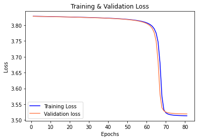

```python
loss_values=train_loss_history
val_loss_values=[loss.item() for loss in val_loss_history]

epochs=range(1,len(loss_values)+1)

plt.plot(epochs,loss_values,'b',label='Training Loss')
plt.plot(epochs,val_loss_values,'b',label='Validation loss',color='coral')
plt.title('Training & Validation Loss')
plt.xlabel('Epochs')
plt.ylabel('Loss')
plt.legend()

plt.show()
```

```python
def test(x_test,model):
    #TELL MODEL IT SHOULD BE EVALUATING
    model.eval()
    X= torch.from_numpy(x_test).to(device).float()
    pred = model(X).argmax(dim=1).numpy()
    return pred
```

```python
#Test Performance
from sklearn.metrics import classification_report
y_pred=test(X_test,model)
print (classification_report(test_labels,y_pred))
```

```
              precision    recall  f1-score   support

           0       0.00      0.00      0.00        12
           1       0.00      0.00      0.00       105
           2       0.00      0.00      0.00        20
           3       0.36      1.00      0.53       813
           4       0.00      0.00      0.00       474
           5       0.00      0.00      0.00         5
           6       0.00      0.00      0.00        14
           7       0.00      0.00      0.00         3
           8       0.00      0.00      0.00        38
           9       0.00      0.00      0.00        25
          10       0.00      0.00      0.00        30
          11       0.00      0.00      0.00        83
          12       0.00      0.00      0.00        13
```

[output cut: 37 more lines]